```python
# Скрыть предупреждения
import warnings
warnings.filterwarnings('ignore')
# Скрытие ячеек кода в формате html
from IPython.display import HTML
HTML('''<script>
  function code_toggle() {
    if (code_shown){
      $('div.input').hide('500');
      $('#toggleButton').val('Show Code')
    } else {
      $('div.input').show('500');
      $('#toggleButton').val('Hide Code')
    }
    code_shown = !code_shown
  }
  $( document ).ready(function(){
    code_shown=false;
    $('div.input').hide()
  });
</script>
<form action="javascript:code_toggle()"><input type="submit" id="toggleButton" value="Show Code"></form>''')
```

# Использование методов машинного обучения в стратегиях связанных с торговлей акциями на Московской бирже

#### Андрюничев Валерий Владимирович

#### 15 октября 2019 года

# Введение

С современным развитием вычислительнх технологий, у аналитиков появился сильный инструмент для анализа большого объема данных. В данной статье приводится пример использования множественной регресси, дерева решений и случайного леса для разработки и анализа стратегии торговли на Московской бирже.

Для анализу выбраны акции 3х компаний: Сбербанк(SBER), Газпром(GAZP), Лукойл(LKOH). Эти акции выбраны в следстивии их большого вклада в значение индекса ММВБ(IMOEX).

Анализ будет проводится в $jupyter lab$ с использованием $Python$ $3.7$. Данные для анализу получены из торговой системы $QUIK$ с использованием $Lua$ скрипта.

Данные по акциям будут состоять из: Лучшей цена спроса $BID$, Спроса по лучшей цене $BIDDEPTH$, Суммарному предложению $BIDDEPTHT$, Количества заявок на покупку $NUMBIDS$, Лучшей цена предложения $OFFER$, Предложеня по лучшей цене $OFFERDEPTH$, Суммарному предложению $OFFERDEPTHT$, Количеству заявок на продажу $NUMOFFERS$, Цене открытия $OPEN$, Максимальной цене $HIGH$, Минимальной цене $LOW$, Цене последней сделки $LAST$, Разнецей между предыдущими сделками $CHANGE$, Оборота последней сделки $QTY$, Объем последней сделки $VALUE$. Также будет добавлена переменная которая показывает рост или подение цены последней сделки и переменная показывающая монотонность падения или роста цены акции. В данном статье будет попытка предсказать переменную роста или падения будующей "последней сделки".

# Описание данных

Данные представяют собой CSV файлы и находятся в [репозитории](https://github.com/Aurilino/Arcticals_data_and_calculations) . Все для расчёта будут данные получены из торговой системы QUIK с помощью языка lua. Код для экспорта находится [репозитории](https://github.com/Aurilino/Arcticals_data_and_calculations) .

Посмотрим на основные характеристики данных.

И добавим к данным будущий рост или падения цены (GROW), и монотонность продолжительности роста или падения цены(MONO).

```python
# Функция для переменной показыващей рост или падение цены
def up_or_down(dataframe, colname = 'GROW'):
    dataframe[colname] = 0
    for row in range(len(dataframe.index)-1):
        if dataframe.loc[row, 'LAST'] < dataframe.loc[row+1, 'LAST']:
            dataframe.loc[row, colname] = 1
        else:
            dataframe.loc[row, colname] = 0

# Функция монотонности роста или падения цены
def mono_grow(dataframe, colname = 'MONO'):
    dataframe[colname] = 1
    number = 1
    for row in range(1, len(dataframe.index)):
        if dataframe.GROW[row] == dataframe.GROW[row-1]:
            number += 1
            dataframe.loc[row, colname] = number
        else:
            number = 1
            dataframe.loc[row, colname] = number
```

```python
# Отображение всех выводов ячейки
from IPython.core.interactiveshell import InteractiveShell
InteractiveShell.ast_node_interactivity = "all"
# Подключим пакет pandas для загрузки данных
from pandas import read_csv as read, Series, DataFrame as DF
# Сбербанк
sber_name_list = ['SBER_1107', 'SBER_1507', 'SBER_1607']
for name in sber_name_list:
    globals()[name] = read('https://raw.githubusercontent.com/Aurilino/Arcticals_data_and_calculations/master/export_' + str(name) + '.txt')
    print(name)
    del globals()[name]['TIME']
    up_or_down(globals()[name])
    mono_grow(globals()[name])
    globals()[name].describe().apply(lambda x: Series.round(x, 2))
    # Газпром
gazp_name_list = ['GAZP_1107', 'GAZP_1507', 'GAZP_1607']
for name in gazp_name_list:
    print(name)
    globals()[name] = read('https://raw.githubusercontent.com/Aurilino/Arcticals_data_and_calculations/master/export_' + str(name) + '.txt')
    del globals()[name]['TIME']
    up_or_down(globals()[name])
    mono_grow(globals()[name])
    globals()[name].describe().apply(lambda x: Series.round(x, 2))
# Лукойл
lkoh_name_list = ['LKOH_1107', 'LKOH_1507', 'LKOH_1607']
for name in lkoh_name_list:
    globals()[name] = read('https://raw.githubusercontent.com/Aurilino/Arcticals_data_and_calculations/master/export_' + str(name) + '.txt')
    print(name)
    del globals()[name]['TIME']
    up_or_down(globals()[name])
    mono_grow(globals()[name])
    globals()[name].describe().apply(lambda x: Series.round(x, 2))
```

```
SBER_1107
```

|  | BID | BIDDEPTH | BIDDEPTHT | NUMBIDS | OFFER | OFFERDEPTH | OFFERDEPTHT | NUMOFFERS | OPEN | HIGH | LOW | LAST | CHANGE | QTY | VALUE | GROW | MONO |
| --- | --- | --- | --- | --- | --- | --- | --- | --- | --- | --- | --- | --- | --- | --- | --- | --- | --- |
| count | 237.00 | 237.00 | 237.00 | 237.00 | 237.00 | 237.00 | 237.00 | 237.00 | 237.0 | 237.00 | 237.00 | 237.00 | 237.00 | 237.0 | 237.00 | 237.00 | 237.00 |
| mean | 242.53 | 295.78 | 236505.72 | 1666.46 | 242.57 | 269.95 | 507618.78 | 2366.05 | 244.5 | 244.97 | 242.00 | 242.55 | -1.21 | 256.1 | 230.42 | 0.46 | 1.98 |
| std | 0.62 | 627.66 | 42684.48 | 166.19 | 0.62 | 456.86 | 48586.29 | 253.07 | 0.0 | 0.00 | 0.63 | 0.62 | 0.62 | 0.0 | 0.70 | 0.50 | 1.22 |
| min | 241.73 | 1.00 | 136360.00 | 1172.00 | 241.76 | 1.00 | 396096.00 | 1765.00 | 244.5 | 244.97 | 241.60 | 241.76 | -2.00 | 256.1 | 230.00 | 0.00 | 1.00 |
| 25% | 242.12 | 51.00 | 206478.00 | 1569.00 | 242.16 | 78.00 | 472828.00 | 2197.00 | 244.5 | 244.97 | 241.60 | 242.15 | -1.61 | 256.1 | 230.00 | 0.00 | 1.00 |
| 50% | 242.35 | 139.00 | 232981.00 | 1649.00 | 242.38 | 150.00 | 518318.00 | 2438.00 | 244.5 | 244.97 | 241.77 | 242.37 | -1.39 | 256.1 | 230.00 | 0.00 | 2.00 |
| 75% | 242.64 | 333.00 | 271246.00 | 1824.00 | 242.67 | 304.00 | 544333.00 | 2546.00 | 244.5 | 244.97 | 242.30 | 242.66 | -1.10 | 256.1 | 231.59 | 1.00 | 3.00 |
| max | 244.41 | 7727.00 | 330124.00 | 1932.00 | 244.44 | 5068.00 | 575680.00 | 2705.00 | 244.5 | 244.97 | 243.62 | 244.44 | 0.68 | 256.1 | 231.59 | 1.00 | 6.00 |

```
SBER_1507
```

|  | BID | BIDDEPTH | BIDDEPTHT | NUMBIDS | OFFER | OFFERDEPTH | OFFERDEPTHT | NUMOFFERS | OPEN | HIGH | LOW | LAST | CHANGE | QTY | VALUE | GROW | MONO |
| --- | --- | --- | --- | --- | --- | --- | --- | --- | --- | --- | --- | --- | --- | --- | --- | --- | --- |
| count | 445.00 | 445.00 | 445.00 | 445.00 | 445.00 | 445.00 | 445.00 | 445.00 | 445.0 | 445.00 | 445.00 | 445.00 | 445.00 | 445.00 | 445.00 | 445.00 | 445.00 |
| mean | 236.79 | 238.92 | 230223.08 | 1976.78 | 236.84 | 450.55 | 385214.00 | 2315.10 | 237.9 | 238.58 | 234.57 | 236.82 | -0.20 | 253.33 | 222.28 | 0.44 | 1.89 |
| std | 0.88 | 353.16 | 52791.15 | 457.55 | 0.87 | 1232.47 | 46439.86 | 306.96 | 0.0 | 0.07 | 0.92 | 0.87 | 0.87 | 2.79 | 0.00 | 0.50 | 1.18 |
| min | 234.51 | 1.00 | 87084.00 | 677.00 | 234.55 | 1.00 | 156064.00 | 1039.00 | 237.9 | 238.17 | 234.23 | 234.54 | -2.48 | 249.00 | 222.28 | 0.00 | 1.00 |
| 25% | 236.20 | 50.00 | 196510.00 | 1784.00 | 236.28 | 71.00 | 376324.00 | 2271.00 | 237.9 | 238.59 | 234.23 | 236.24 | -0.78 | 252.28 | 222.28 | 0.00 | 1.00 |
| 50% | 236.78 | 108.00 | 238621.00 | 2091.00 | 236.80 | 181.00 | 392540.00 | 2366.00 | 237.9 | 238.59 | 234.23 | 236.80 | -0.22 | 252.28 | 222.28 | 0.00 | 1.00 |
| 75% | 237.49 | 289.00 | 278255.00 | 2306.00 | 237.54 | 356.00 | 415042.00 | 2488.00 | 237.9 | 238.59 | 234.23 | 237.54 | 0.52 | 257.67 | 222.28 | 1.00 | 2.00 |
| max | 238.48 | 3006.00 | 314760.00 | 2603.00 | 238.52 | 15862.00 | 446903.00 | 2703.00 | 237.9 | 238.59 | 237.40 | 238.52 | 1.50 | 257.67 | 222.28 | 1.00 | 7.00 |

```
SBER_1607
```

|  | BID | BIDDEPTH | BIDDEPTHT | NUMBIDS | OFFER | OFFERDEPTH | OFFERDEPTHT | NUMOFFERS | OPEN | HIGH | LOW | LAST | CHANGE | QTY | VALUE | GROW | MONO |
| --- | --- | --- | --- | --- | --- | --- | --- | --- | --- | --- | --- | --- | --- | --- | --- | --- | --- |
| count | 418.00 | 418.00 | 418.00 | 418.00 | 418.00 | 418.00 | 418.00 | 418.00 | 418.00 | 418.0 | 418.00 | 418.00 | 418.00 | 418.00 | 418.00 | 418.00 | 418.00 |
| mean | 233.67 | 279.17 | 261725.97 | 1863.93 | 233.72 | 374.03 | 325370.95 | 2292.41 | 234.68 | 235.3 | 232.78 | 233.70 | -1.57 | 255.89 | 222.51 | 0.46 | 1.89 |
| std | 0.47 | 458.40 | 22585.58 | 220.71 | 0.47 | 1477.93 | 40000.34 | 249.42 | 0.00 | 0.0 | 0.38 | 0.47 | 0.47 | 0.00 | 1.85 | 0.50 | 1.23 |
| min | 232.60 | 1.00 | 199842.00 | 1323.00 | 232.65 | 1.00 | 202032.00 | 1457.00 | 234.68 | 235.3 | 232.25 | 232.60 | -2.67 | 255.89 | 220.00 | 0.00 | 1.00 |
| 25% | 233.34 | 50.00 | 245785.00 | 1735.50 | 233.39 | 77.00 | 304649.50 | 2149.25 | 234.68 | 235.3 | 232.70 | 233.38 | -1.89 | 255.89 | 220.00 | 0.00 | 1.00 |
| 50% | 233.68 | 144.50 | 265507.00 | 1896.00 | 233.74 | 167.50 | 335946.50 | 2345.50 | 234.68 | 235.3 | 232.82 | 233.72 | -1.55 | 255.89 | 223.87 | 0.00 | 1.00 |
| 75% | 234.00 | 314.75 | 276683.00 | 2047.00 | 234.03 | 325.00 | 354891.00 | 2510.75 | 234.68 | 235.3 | 232.82 | 234.03 | -1.24 | 255.89 | 223.87 | 1.00 | 2.00 |
| max | 234.79 | 4805.00 | 307692.00 | 2220.00 | 234.81 | 26028.00 | 387932.00 | 2630.00 | 234.68 | 235.3 | 233.57 | 234.81 | -0.46 | 255.89 | 223.87 | 1.00 | 8.00 |

```
GAZP_1107
```

|  | BID | BIDDEPTH | BIDDEPTHT | NUMBIDS | OFFER | OFFERDEPTH | OFFERDEPTHT | NUMOFFERS | OPEN | HIGH | LOW | LAST | CHANGE | QTY | VALUE | GROW | MONO |
| --- | --- | --- | --- | --- | --- | --- | --- | --- | --- | --- | --- | --- | --- | --- | --- | --- | --- |
| count | 237.00 | 237.00 | 237.00 | 237.00 | 237.00 | 237.00 | 237.00 | 237.00 | 237.0 | 237.00 | 237.00 | 237.00 | 237.00 | 237.00 | 237.00 | 237.00 | 237.00 |
| mean | 248.22 | 370.45 | 379046.31 | 3703.11 | 248.27 | 1730.68 | 369985.92 | 2198.68 | 250.0 | 250.69 | 247.37 | 248.25 | -1.96 | 268.44 | 233.70 | 0.45 | 1.71 |
| std | 0.77 | 1036.54 | 48620.86 | 446.89 | 0.77 | 11709.71 | 64251.14 | 237.09 | 0.0 | 0.00 | 1.15 | 0.77 | 0.77 | 3.64 | 2.97 | 0.50 | 1.05 |
| min | 246.66 | 1.00 | 249350.00 | 2389.00 | 246.73 | 1.00 | 270736.00 | 1700.00 | 250.0 | 250.69 | 246.36 | 246.63 | -3.58 | 260.00 | 231.50 | 0.00 | 1.00 |
| 25% | 247.61 | 50.00 | 348295.00 | 3355.00 | 247.64 | 88.00 | 333848.00 | 2008.00 | 250.0 | 250.69 | 246.36 | 247.62 | -2.59 | 270.00 | 231.50 | 0.00 | 1.00 |
| 50% | 248.30 | 147.00 | 378305.00 | 3766.00 | 248.34 | 194.00 | 366210.00 | 2322.00 | 250.0 | 250.69 | 246.36 | 248.33 | -1.88 | 270.00 | 231.50 | 0.00 | 1.00 |
| 75% | 248.89 | 275.00 | 425442.00 | 4076.00 | 248.96 | 416.00 | 383741.00 | 2396.00 | 250.0 | 250.69 | 248.61 | 248.93 | -1.28 | 270.00 | 237.70 | 1.00 | 2.00 |
| max | 249.53 | 7952.00 | 448268.00 | 4375.00 | 249.59 | 109768.00 | 597886.00 | 2466.00 | 250.0 | 250.69 | 249.22 | 249.58 | -0.63 | 270.00 | 237.70 | 1.00 | 6.00 |

```
GAZP_1507
```

|  | BID | BIDDEPTH | BIDDEPTHT | NUMBIDS | OFFER | OFFERDEPTH | OFFERDEPTHT | NUMOFFERS | OPEN | HIGH | LOW | LAST | CHANGE | QTY | VALUE | GROW | MONO |
| --- | --- | --- | --- | --- | --- | --- | --- | --- | --- | --- | --- | --- | --- | --- | --- | --- | --- |
| count | 445.00 | 445.00 | 445.00 | 445.00 | 445.00 | 445.00 | 445.00 | 445.00 | 445.00 | 445.00 | 445.00 | 445.00 | 445.00 | 445.00 | 445.00 | 445.00 | 445.00 |
| mean | 244.36 | 219.80 | 313692.49 | 2609.47 | 244.42 | 283.70 | 464414.40 | 2677.69 | 246.98 | 248.07 | 243.65 | 244.40 | -1.10 | 258.89 | 235.62 | 0.42 | 1.93 |
| std | 0.99 | 433.13 | 59530.35 | 427.58 | 1.00 | 482.01 | 75234.62 | 438.77 | 0.00 | 0.11 | 0.88 | 1.00 | 1.00 | 4.87 | 1.35 | 0.49 | 1.17 |
| min | 241.17 | 1.00 | 120555.00 | 1410.00 | 241.23 | 1.00 | 136957.00 | 1068.00 | 246.98 | 246.98 | 241.13 | 241.23 | -4.27 | 255.52 | 232.00 | 0.00 | 1.00 |
| 25% | 244.02 | 31.00 | 263914.00 | 2272.00 | 244.08 | 89.00 | 459029.00 | 2465.00 | 246.98 | 248.08 | 243.33 | 244.06 | -1.44 | 256.00 | 235.39 | 0.00 | 1.00 |
| 50% | 244.43 | 114.00 | 316979.00 | 2703.00 | 244.49 | 197.00 | 496855.00 | 2873.00 | 246.98 | 248.08 | 243.33 | 244.46 | -1.04 | 256.00 | 235.39 | 0.00 | 2.00 |
| 75% | 244.73 | 221.00 | 361231.00 | 2960.00 | 244.80 | 400.00 | 506782.00 | 2946.00 | 246.98 | 248.08 | 244.00 | 244.77 | -0.73 | 267.04 | 235.39 | 1.00 | 2.00 |
| max | 247.84 | 5235.00 | 439210.00 | 3275.00 | 247.89 | 7540.00 | 540074.00 | 3289.00 | 246.98 | 248.08 | 246.27 | 247.89 | 2.39 | 267.04 | 238.55 | 1.00 | 6.00 |

```
GAZP_1607
```

|  | BID | BIDDEPTH | BIDDEPTHT | NUMBIDS | OFFER | OFFERDEPTH | OFFERDEPTHT | NUMOFFERS | OPEN | HIGH | LOW | LAST | CHANGE | QTY | VALUE | GROW | MONO |
| --- | --- | --- | --- | --- | --- | --- | --- | --- | --- | --- | --- | --- | --- | --- | --- | --- | --- |
| count | 418.00 | 418.00 | 418.00 | 418.00 | 418.00 | 418.00 | 418.00 | 418.00 | 418.00 | 418.0 | 418.00 | 418.00 | 418.00 | 418.00 | 418.0 | 418.00 | 418.00 |
| mean | 237.48 | 320.88 | 356167.90 | 3041.53 | 237.51 | 185.40 | 503607.35 | 2856.09 | 240.01 | 240.4 | 236.88 | 237.49 | -2.81 | 276.86 | 210.0 | 0.42 | 1.82 |
| std | 0.81 | 592.29 | 23483.58 | 362.87 | 0.82 | 507.02 | 40735.72 | 341.19 | 0.00 | 0.0 | 0.65 | 0.82 | 0.82 | 0.00 | 0.0 | 0.49 | 1.10 |
| min | 235.89 | 1.00 | 218057.00 | 2113.00 | 235.95 | 1.00 | 393799.00 | 1868.00 | 240.01 | 240.4 | 235.83 | 235.89 | -4.41 | 276.86 | 210.0 | 0.00 | 1.00 |
| 25% | 236.66 | 81.00 | 342955.00 | 2776.25 | 236.69 | 6.00 | 495630.25 | 2634.75 | 240.01 | 240.4 | 236.04 | 236.66 | -3.64 | 276.86 | 210.0 | 0.00 | 1.00 |
| 50% | 237.73 | 173.00 | 360310.00 | 3047.00 | 237.76 | 86.50 | 519644.00 | 2928.00 | 240.01 | 240.4 | 237.41 | 237.73 | -2.58 | 276.86 | 210.0 | 0.00 | 1.00 |
| 75% | 238.13 | 343.50 | 369645.50 | 3356.75 | 238.18 | 192.50 | 528510.50 | 3151.75 | 240.01 | 240.4 | 237.41 | 238.15 | -2.15 | 276.86 | 210.0 | 1.00 | 2.00 |
| max | 239.46 | 6203.00 | 397892.00 | 3692.00 | 239.51 | 8505.00 | 566285.00 | 3263.00 | 240.01 | 240.4 | 237.41 | 239.51 | -0.79 | 276.86 | 210.0 | 1.00 | 7.00 |

```
LKOH_1107
```

|  | BID | BIDDEPTH | BIDDEPTHT | NUMBIDS | OFFER | OFFERDEPTH | OFFERDEPTHT | NUMOFFERS | OPEN | HIGH | LOW | LAST | CHANGE | QTY | VALUE | GROW | MONO |
| --- | --- | --- | --- | --- | --- | --- | --- | --- | --- | --- | --- | --- | --- | --- | --- | --- | --- |
| count | 237.00 | 237.00 | 237.00 | 237.00 | 237.00 | 237.00 | 237.00 | 237.00 | 237.0 | 237.0 | 237.00 | 237.00 | 237.00 | 237.0 | 237.0 | 237.00 | 237.00 |
| mean | 5304.82 | 126.06 | 40429.74 | 784.51 | 5306.13 | 119.90 | 201538.30 | 1237.75 | 5368.5 | 5374.5 | 5292.72 | 5305.78 | -59.22 | 5500.0 | 5097.0 | 0.40 | 1.99 |
| std | 11.79 | 347.43 | 4777.74 | 91.14 | 11.84 | 130.26 | 8009.26 | 128.75 | 0.0 | 0.0 | 13.27 | 11.77 | 11.77 | 0.0 | 0.0 | 0.49 | 1.41 |
| min | 5282.50 | 1.00 | 30262.00 | 531.00 | 5284.50 | 1.00 | 183965.00 | 917.00 | 5368.5 | 5374.5 | 5282.50 | 5284.50 | -80.50 | 5500.0 | 5097.0 | 0.00 | 1.00 |
| 25% | 5300.00 | 21.00 | 37047.00 | 716.00 | 5301.00 | 58.00 | 195157.00 | 1206.00 | 5368.5 | 5374.5 | 5287.00 | 5301.00 | -64.00 | 5500.0 | 5097.0 | 0.00 | 1.00 |
| 50% | 5304.50 | 69.00 | 40550.00 | 803.00 | 5306.00 | 76.00 | 205295.00 | 1266.00 | 5368.5 | 5374.5 | 5287.00 | 5305.50 | -59.50 | 5500.0 | 5097.0 | 0.00 | 1.00 |
| 75% | 5309.00 | 99.00 | 43423.00 | 852.00 | 5310.50 | 139.00 | 206917.00 | 1297.00 | 5368.5 | 5374.5 | 5297.00 | 5310.00 | -55.00 | 5500.0 | 5097.0 | 1.00 | 2.00 |
| max | 5341.50 | 4484.00 | 50259.00 | 929.00 | 5342.00 | 980.00 | 213467.00 | 1423.00 | 5368.5 | 5374.5 | 5335.50 | 5341.50 | -23.50 | 5500.0 | 5097.0 | 1.00 | 9.00 |

```
LKOH_1507
```

|  | BID | BIDDEPTH | BIDDEPTHT | NUMBIDS | OFFER | OFFERDEPTH | OFFERDEPTHT | NUMOFFERS | OPEN | HIGH | LOW | LAST | CHANGE | QTY | VALUE | GROW | MONO |
| --- | --- | --- | --- | --- | --- | --- | --- | --- | --- | --- | --- | --- | --- | --- | --- | --- | --- |
| count | 445.00 | 445.00 | 445.00 | 445.00 | 445.00 | 445.00 | 445.00 | 445.00 | 445.0 | 445.0 | 445.00 | 445.00 | 445.00 | 445.00 | 445.00 | 445.00 | 445.00 |
| mean | 5178.23 | 147.34 | 43674.08 | 1046.43 | 5179.68 | 179.38 | 186019.65 | 1157.63 | 5254.0 | 5263.5 | 5162.67 | 5178.91 | -84.09 | 5483.43 | 4918.80 | 0.41 | 1.93 |
| std | 18.15 | 263.24 | 7879.67 | 246.87 | 18.30 | 175.82 | 11801.84 | 165.53 | 0.0 | 0.0 | 18.58 | 18.33 | 18.33 | 138.46 | 62.73 | 0.49 | 1.29 |
| min | 5152.00 | 1.00 | 21955.00 | 308.00 | 5153.00 | 1.00 | 58108.00 | 535.00 | 5254.0 | 5263.5 | 5151.50 | 5152.00 | -111.00 | 5368.00 | 4900.00 | 0.00 | 1.00 |
| 25% | 5163.50 | 68.00 | 40378.00 | 940.00 | 5165.00 | 70.00 | 183452.00 | 1090.00 | 5254.0 | 5263.5 | 5151.50 | 5164.00 | -99.00 | 5415.00 | 4900.00 | 0.00 | 1.00 |
| 50% | 5177.00 | 100.00 | 44975.00 | 1110.00 | 5178.50 | 124.00 | 187984.00 | 1185.00 | 5254.0 | 5263.5 | 5162.00 | 5178.00 | -85.00 | 5415.00 | 4900.00 | 0.00 | 1.00 |
| 75% | 5187.50 | 193.00 | 47201.00 | 1204.00 | 5189.00 | 217.00 | 190282.00 | 1282.00 | 5254.0 | 5263.5 | 5162.00 | 5188.50 | -74.50 | 5713.00 | 4900.00 | 1.00 | 2.00 |
| max | 5251.50 | 5144.00 | 57227.00 | 1375.00 | 5254.00 | 1456.00 | 198634.00 | 1362.00 | 5254.0 | 5263.5 | 5241.50 | 5254.00 | -9.00 | 5713.00 | 5158.00 | 1.00 | 9.00 |

```
LKOH_1607
```

|  | BID | BIDDEPTH | BIDDEPTHT | NUMBIDS | OFFER | OFFERDEPTH | OFFERDEPTHT | NUMOFFERS | OPEN | HIGH | LOW | LAST | CHANGE | QTY | VALUE | GROW | MONO |
| --- | --- | --- | --- | --- | --- | --- | --- | --- | --- | --- | --- | --- | --- | --- | --- | --- | --- |
| count | 418.00 | 418.00 | 418.00 | 418.00 | 418.00 | 418.00 | 418.00 | 418.00 | 418.0 | 418.0 | 418.00 | 418.00 | 418.00 | 418.0 | 418.00 | 418.00 | 418.00 |
| mean | 5147.14 | 155.67 | 35995.33 | 969.03 | 5148.40 | 226.92 | 172972.72 | 1160.80 | 5177.0 | 5200.5 | 5130.57 | 5147.67 | -30.83 | 5619.5 | 4908.01 | 0.42 | 1.82 |
| std | 12.88 | 161.72 | 5149.69 | 164.86 | 12.99 | 247.35 | 5086.45 | 112.31 | 0.0 | 0.0 | 9.66 | 12.95 | 12.95 | 0.0 | 8.26 | 0.49 | 1.12 |
| min | 5125.00 | 1.00 | 21882.00 | 561.00 | 5126.50 | 1.00 | 158973.00 | 779.00 | 5177.0 | 5200.5 | 5125.00 | 5125.50 | -53.00 | 5619.5 | 4900.00 | 0.00 | 1.00 |
| 25% | 5135.50 | 70.00 | 32939.50 | 915.00 | 5136.50 | 69.00 | 168646.50 | 1089.25 | 5177.0 | 5200.5 | 5127.50 | 5136.00 | -42.50 | 5619.5 | 4900.00 | 0.00 | 1.00 |
| 50% | 5142.50 | 120.00 | 36021.00 | 1008.00 | 5143.50 | 115.00 | 173914.00 | 1201.00 | 5177.0 | 5200.5 | 5127.50 | 5143.00 | -35.50 | 5619.5 | 4900.00 | 0.00 | 1.00 |
| 75% | 5159.00 | 203.50 | 39185.75 | 1103.75 | 5160.38 | 312.25 | 177461.50 | 1254.00 | 5177.0 | 5200.5 | 5127.50 | 5159.88 | -18.62 | 5619.5 | 4916.50 | 1.00 | 2.00 |
| max | 5184.50 | 2169.00 | 48225.00 | 1171.00 | 5186.00 | 1168.00 | 180870.00 | 1294.00 | 5177.0 | 5200.5 | 5158.50 | 5183.50 | 5.00 | 5619.5 | 4916.50 | 1.00 | 8.00 |

Посмотрим на распределение изменения цены последней сделки.

```
Cбербанк
```

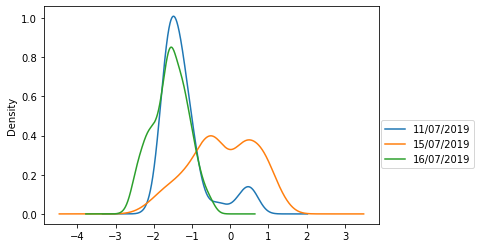

```python
# Подкючим графические пакеты
import matplotlib as plt
import seaborn as sns
# Распечатаем распределения для Сбербанка
labels = ['11/07/2019', '15/07/2019', '16/07/2019']
step = 0
for name in sber_name_list:
    ax = globals()[name].CHANGE.plot.kde(legend=False, label=labels[step]).legend(bbox_to_anchor=(1.3, 0.5))
    step += 1
print('Cбербанк')
```

```
Газпром
```

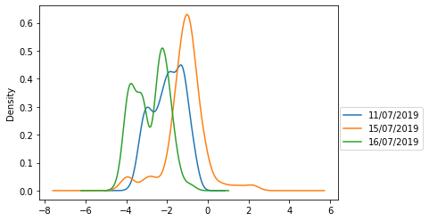

```python
# Распечатаем распределения для Газпрома
step = 0
for name in gazp_name_list:
    ax = globals()[name].CHANGE.plot.kde(legend=False, label=labels[step]).legend(bbox_to_anchor=(1.3, 0.5))
    step += 1
print('Газпром')
```

```
Лукойл
```

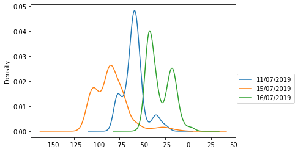

```python
# Распечатаем распределения для Лукойла
step = 0
for name in lkoh_name_list:
    ax = globals()[name].CHANGE.plot.kde(legend=False, label=labels[step]).legend(bbox_to_anchor=(1.3, 0.5))
    step += 1
print('Лукойл')
```

По полученым данным можно сказать, что в основном у всех акций в эти дни наблюдалось падение цены последней сделки.

# Стратегия с использованием множественной регрессии

Регрессия - это отражение зависимости одной переменной от другой независимой переменной. Для регрессии с одной независимой переменной фомула расчёта зависимой переменой имеет вид:

$\widehat y_i = \beta_0 + \beta_1 x_i + \epsilon$

Где:

- $\widehat y_i$ - предсазанное значение $y_i$;

- $\beta_0$ и $\beta_1$ - параметры модели;

- $\epsilon$ - ошибка модели.

Коэффициент $\beta_0$ это персечение прямой заданной вектором из всех $\widehat y_i$ с осью ординат, для получения ланного параметра небходим приравнять значения всех $x_i$ единице. А Коэффициент $\beta_1$ показывает зависимость $\widehat y_i$ от $x_i$ и находится по формуле:

$\beta_1=\frac{\sum_{i=1}^{n}(x_i - \overline x)(y_i - \overline y)}{\sum_{i=1}^{n}(x_i - \overline x)^2}$

Где:

- $\beta_1$ - параметр регрессии опредляющий вклад переменной $x$ в значение $y$;.

- $x_i$ и $y_i$ - значение $x$ и $y$ соттветственно; - $\overline x$ и $\overline y$ - среднее значение $x$ и $y$ соттветственно.

Для определения множества $\beta$ ($\beta_0$, $\beta_1$, $\beta_2$, ... , $\beta_2$) используются матрицы. Значения $y$ можно представить как вектор $\vec y=[y_0,y_1, ... ,y_n]$, а свободные переменные $x_0$, $x_1$, ..., $x_n$ можно представить как матрицу $\vec x_{i}^{j}=\big[{x_{i1}, x_{i2}, ..., x_{in} \atop x_{j1}, x_{j2}, ..., x_{jn}}\big]$, соответственно множество $\beta$ можно представить как вектор $\vec \beta = [\beta_0, \beta_1, ... ,\beta_n]$. А формула расчета $\vec \beta$:

$\vec \beta = (\vec x^{T} \vec x)^{-1} \vec x^{T} \vec y$

## Методика расчёта стратегии

Стратегия строится на определении показателей $\vec \beta$ для расчётного окна и применение полученных показателей $\vec \beta$ к следующему шагу. Для каждго шага $\vec \beta$ расчитываетя на основе нового расчётного окна. Расчёты будут проводится с помощью "numpy".

```python
all_names = sber_name_list + gazp_name_list + lkoh_name_list
for name in all_names:
    # Здададим значения для определения параметров пересечения
    globals()[name]['BASE'] = 1
```

Рассчитаем стратегию и посмотрим на эффективность.

```python
import numpy as np # Пакет для математических операций
# Функции нахождение параметров регрессии
def regression_coef(X, y):
    # произведение транспонированной матрицы независимых перемен и матрицу независимых перемен
    step1 = X.T.dot(X)
    # Получение обратной матрицы
    step2 = np.linalg.inv(step1)
    # произведение обратной матрицы и матрицы независимых перемен
    step3 = step2.dot(X.T)
    # получение параметров регрессии путем умножения полученной матрицы на матрицу зависимой переменной
    return step3.dot(y)
```

```python
regression_results = DF()
step = 110
for name in all_names:
    results = []
    for window_leigth in range(10, step, 10):
        # создадим тренировочную выборку
        train = globals()[name].loc[1:window_leigth]
        y = np.array([train.GROW]) # зависимая переменная
        X = np.array(train.drop('GROW', axis=1)) # Независимые переменные
        # Опредлим пораметры регрессии
        b = regression_coef(X, y.T)
        # создадим тестовую выборку
        test = globals()[name].loc[window_leigth:]
        y_test = np.array([test.GROW]) # зависимая переменная
        X_test = np.array(test.drop('GROW', axis=1)) # Независимые переменные
        # получим вектор результатов
        res = np.array(b.T).dot(np.array(X_test.T)).T
        # найдем среднюю разность между расчётными и фактическими значениями
        error = ((y_test - res.T).sum()) / len(res)
        results.append(error)
    regression_results[name] = results
regression_results.index = [str(i) for i in range(10, step, 10)]
regression_results.index.name = 'Step_leight'
regression_results
```

| Step_leight | SBER_1107 | SBER_1507 | SBER_1607 | GAZP_1107 | GAZP_1507 | GAZP_1607 | LKOH_1107 | LKOH_1507 | LKOH_1607 |
| --- | --- | --- | --- | --- | --- | --- | --- | --- | --- |
| 10 | -8739.269910 | 72.031045 | -19.908060 | -21218.339226 | -9.729565 | -2724.868964 | -18.116517 | -11.381725 | -51490.419527 |
| 20 | 12140.885141 | 107.310675 | 19.169406 | 133.129952 | 16.693884 | -0.256458 | 5.969588 | 107.912224 | -26618.095924 |
| 30 | 3.639478 | 29.189827 | 6.845586 | 9.080941 | 13.724413 | -0.454047 | 6.545477 | 113.754344 | 0.372431 |
| 40 | -3.113261 | -4.098967 | 6.876305 | 128.802116 | 28.395618 | 0.435425 | 1.026946 | 16.818571 | -9.020494 |
| 50 | -3.561212 | 3.984971 | 2.017141 | 5.884649 | 67.746831 | 0.284458 | 1.838740 | 53.850329 | -0.191224 |
| 60 | 3.055664 | -0.447673 | 3.171340 | 104.186199 | 1.145128 | 11128.366850 | -1.732544 | -6.637513 | 10.617460 |
| 70 | 0.593266 | -0.317079 | -1.090958 | -0.957051 | 2.218787 | -0.480361 | 0.544888 | 1657.513043 | 5.561624 |
| 80 | 0.864363 | 0.275254 | 3.159451 | -3.378706 | 1.874030 | 9.481298 | 1.319952 | -23.139466 | 0.193107 |
| 90 | 0.082115 | 0.770907 | -0.983904 | -1.739587 | 1.554903 | 0.274522 | -1.018592 | 83.366793 | 3.485173 |
| 100 | 0.201028 | 0.338074 | -1.790049 | 4.660245 | 1.171637 | 0.728878 | -0.551278 | 0.368563 | 1.383292 |

# Стратегия с использованием дерева решения

Дерево решения один из множества методов машинного обучения. Дерево решений представляет собой структуру состоящей из листьев и ветвей. На ветвях находятся атрибуты, которых определяют результат целевой функции, а листья представляют собой целевую функцию, а в остальных узлах — атрибуты, по которым различаются случаи.

Разберем метод работы дерева решений. Для начала предствим, что есть таблица.

```python
import pandas as pd # Пакет для создание и работы с данными
DF({'X_1': [1, 1, 1, 0, 0, 0, 1, 1, 1, 0],
    'X_2': [1, 0, 1, 0, 1, 1, 0, 1, 0, 0],
    'Y': [0, 1, 0, 0, 1, 1, 1, 0, 1, 0,]})
```

|  | X_1 | X_2 | Y |
| --- | --- | --- | --- |
| 0 | 1 | 1 | 0 |
| 1 | 1 | 0 | 1 |
| 2 | 1 | 1 | 0 |
| 3 | 0 | 0 | 0 |
| 4 | 0 | 1 | 1 |
| 5 | 0 | 1 | 1 |
| 6 | 1 | 0 | 1 |
| 7 | 1 | 1 | 0 |
| 8 | 1 | 0 | 1 |
| 9 | 0 | 0 | 0 |

Как мы можем видеть, перед нами $XOR$ или исключающее или. С $XOR$ большенство стандартных класификаторов не работает и выдает неправельные результаты. Однако дерево решений хорошо работает с $XOR$. Основым методом работы дерева решения является уменьшение энтропии на максимальное значение на каждом шаге, значение энтропии лежит в предлах $0,1$ для вычисление энтропии используюется следующая фомула:

$I = -{{\sum_{i=1}^{n}} p_i * log_2(p_i)}$

Где:

- $I$ - количество информации(Величина энтропии);.

- $p_i$ - вероятность отдельного союытия; - $n$ - количество возможных событий.

Так например, дерево решений сначала проверит на сколько уменьшется интропия для $X_1$ и $X_2$. Из них оно выберет тот параметр который максимально уменьшает энтропию. Ниже преведен пример работы дерева решений.

```python
from sklearn.tree import DecisionTreeClassifier # Дерево решений
from sklearn.tree import export_graphviz # Данные  для отрисовки дерева решений
from IPython.display import SVG # отрисовка дерева решений
from IPython.display import display # отображение графике в блокноте
from graphviz import Source # отображение графике в блокноте
from IPython.display import HTML # отображение графике в типе HTML
style = "<style>svg{width:80% !important;height:80% !important;}</style>"
HTML(style)
import os # путь к файлу с модулем Graphviz
os.environ["PATH"] += os.pathsep + 'C:/Program Files/Graphviz2.38/bin'
data = pd.DataFrame({'X_1': [1, 1, 1, 0, 0, 0, 1, 1, 1, 0],
                     'X_2': [1, 0, 1, 0, 1, 1, 0, 1, 0, 0],
                     'Y': [0, 1, 0, 0, 1, 1, 1, 0, 1, 0,]})
# создание дерева решений
clf = DecisionTreeClassifier(criterion='entropy')
# отображение дерево решений
graph = Source(export_graphviz(clf.fit(data[['X_1', 'X_2']], data.Y), out_file=None,
                                    feature_names=list(data[['X_1', 'X_2']]),
                                    class_names=['X_1', 'X_2'],
                                    filled=True))
# вывод дерева решения в ноубуке
display(SVG(graph.pipe(format='svg')))
```

[figure not shown]

Проверим получившееся дерево на тестовых данных.

```python
data_test = pd.DataFrame({'X_1': [0, 1, 0, 1, 0, 1, 0, 1, 0, 1],
                          'X_2': [1, 1, 1, 1, 1, 0, 0, 0, 0, 0],
                          'Y': [1, 0, 1, 0, 1, 1, 0, 1, 0, 1,]})
data_test['Y_predict'] = clf.fit(data[['X_1', 'X_2']], data.Y).predict(data_test[['X_1', 'X_2']])
data_test
```

|  | X_1 | X_2 | Y | Y_predict |
| --- | --- | --- | --- | --- |
| 0 | 0 | 1 | 1 | 1 |
| 1 | 1 | 1 | 0 | 0 |
| 2 | 0 | 1 | 1 | 1 |
| 3 | 1 | 1 | 0 | 0 |
| 4 | 0 | 1 | 1 | 1 |
| 5 | 1 | 0 | 1 | 1 |
| 6 | 0 | 0 | 0 | 0 |
| 7 | 1 | 0 | 1 | 1 |
| 8 | 0 | 0 | 0 | 0 |
| 9 | 1 | 0 | 1 | 1 |

Как видно, класификатор точно предсказал показания на тестовой выборке.

## Методика расчёта стратегии

В начале также определяется длинна расчетного окна. Расчёт окна будет проводиться на выборке $10$ - $100$ фреймов с шагом $10$ фреймов одного дня, потом эти расчеты будут производить на других днях и будет выбрана самая стабильная длина расчётного окна.

На следующем шаге, будет испытана стратегия с применением дерева решений на расчетном окне. И потом будет протестированна стратегия использующая данную модель.

У дерева решений очень много параметров, одним из основных является глубина дерева. Чем больше глубина, тем более большое дерево мы получи. Это может привести к переобучению дерева. По своей сути дерево научится очень хорошо решать тренировочную выборку, а на тестовых выборках такое дерево будет показывать плохой результат.

Посмотрим на структуру дерева решения для данных по акциям.

```python
clf = DecisionTreeClassifier(criterion='entropy')
graph = Source(export_graphviz(clf.fit(SBER_1107.drop('GROW', axis=1), SBER_1107.GROW), out_file=None,
                                    feature_names=[i for i in SBER_1107.drop('GROW', axis=1).columns],
                                    class_names=[i for i in SBER_1107.drop('GROW', axis=1).columns],
                                    filled=True))
display(SVG(graph.pipe(format='svg')))
```

[figure not shown]

Как видно дерево решени имеет очень большую глубину. Посмотрим, как изменятся результат предстказания в зависимости от максимальной глубины.

```python
# Пакет для разбиение выборки на тестовую и тренировочную
from sklearn.model_selection import train_test_split
```

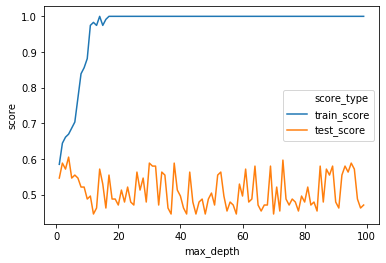

```python
# Список максимальных длин
max_depth_values = range(1,100)
# Датафрейм с результатами
scores = pd.DataFrame()
# Разбиение выборки на тренировочную и тестyвую
X = SBER_1107.drop('GROW', axis=1)
y = SBER_1107.GROW
X_train, X_test, Y_train, Y_test =  train_test_split(X, y, test_size=.50, random_state=42)
for i in max_depth_values:
    # Тренировка дерева с заданной глубиной
    clf = DecisionTreeClassifier(criterion='entropy', max_depth=i)
    train_score = clf.fit(X_train, Y_train).score(X_train, Y_train)
    test_score = clf.fit(X_train, Y_train).score(X_test, Y_test)
    temp = pd.DataFrame({'max_depth': [i],
                        'train_score': [train_score],
                        'test_score': [test_score]})
    scores = scores.append(temp)
scores = pd.melt(scores, id_vars=['max_depth'],
                value_vars=['train_score', 'test_score'],
                var_name='score_type', value_name='score')
ax = sns.lineplot(x='max_depth', y='score', hue='score_type', data = scores)
```

Как и следовало ожидать, переобученная модель показывает плохие результаты на тестовой выборке. Использую методы пакета $sklearn$ подберем оптимальную глубину.

```python
# Поиск лучших параметров для дерева решений
from sklearn.model_selection import GridSearchCV
# Параметры
parametrs = {'criterion': ['gini', 'entropy'], 'max_depth':range(1, 100)}
grid_search_cv_clf = GridSearchCV(DecisionTreeClassifier(), parametrs, iid=True, cv=5)

print('Лучший параметр классификации:', grid_search_cv_clf.fit(SBER_1107.drop('GROW', axis=1), SBER_1107.GROW).best_params_['criterion'])
print('Эффективная глубина:', grid_search_cv_clf.fit(SBER_1107.drop('GROW', axis=1), SBER_1107.GROW).best_params_['max_depth'])
```

```
Лучший параметр классификации: gini
Эффективная глубина: 2
```

Самой лучшей глубиной в данном случае является глубина $2$. Это говорит об малом числе факторов в нашей выборке которое по расчётам дерева решений влияент на рост или падение цены. Построим график влияния параметра на результат классификатора.

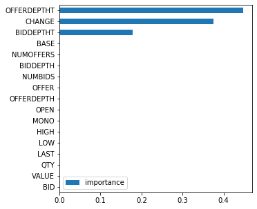

```python
clf = DecisionTreeClassifier(criterion='gini', max_depth=2)
imp = pd.DataFrame(clf.fit(SBER_1107.drop('GROW', axis=1), SBER_1107.GROW).feature_importances_,
              index=SBER_1107.drop('GROW', axis=1).columns, columns=['importance'])
ax = imp.sort_values('importance').plot(kind='barh', figsize=(5, 5))
```

```python
graph = Source(export_graphviz(clf.fit(SBER_1107.drop('GROW', axis=1), SBER_1107.GROW), out_file=None,
                                    feature_names=[i for i in SBER_1107.drop('GROW', axis=1).columns],
                                    class_names=[i for i in SBER_1107.drop('GROW', axis=1).columns],
                                    filled=True))
display(SVG(graph.pipe(format='svg')))
```

[figure not shown]

Найдем оптимальную длину рассчётного окна. Для каждой выборки будем использовать свои лучшие параметры для дерева решений.

```python
tree_results = DF()
step = 110
for name in all_names:
    results = []
    for window_leigth in range(10, step, 10):
        # создадим тренировочную выборку
        train = globals()[name].loc[1:window_leigth]
        y = train.GROW # зависимая переменная
        X = train.drop('GROW', axis=1) # Независимые переменные
        # рассчитаем дерево решения
        ## Параметры модели
        parametrs = {'criterion': ['gini', 'entropy'], 'max_depth':range(1, 30)}
        # Создаем дерево решений с лучшими параметрами
        grid_search_cv_clf = GridSearchCV(DecisionTreeClassifier(), parametrs, iid=True, cv=2)
        # Тренируем дерево решений
        best_clf = grid_search_cv_clf.fit(X, y).best_estimator_
        # создадим тестовую выборку
        test = globals()[name].loc[window_leigth:]
        y_test = test.GROW # зависимая переменная
        X_test = test.drop('GROW', axis=1) # Независимые переменные
        # Эффективность тренированного дерева решений
        res = best_clf.score(X_test, y_test)
        results.append(res)
    tree_results[name] = results
tree_results.index = [str(i) for i in range(10, step, 10)]
tree_results.index.name = 'Step_leight'
# Рассчитем среднее значение эффективности для каждой длины окна
tree_results['MEAN'] = 0
tree_results['MEAN'] = tree_results.sum(axis = 1) / len(tree_results.columns)
tree_results
```

| Step_leight | SBER_1107 | SBER_1507 | SBER_1607 | GAZP_1107 | GAZP_1507 | GAZP_1607 | LKOH_1107 | LKOH_1507 | LKOH_1607 | MEAN |
| --- | --- | --- | --- | --- | --- | --- | --- | --- | --- | --- |
| 10 | 0.493392 | 0.544828 | 0.541667 | 0.546256 | 0.418391 | 0.580882 | 0.387665 | 0.413793 | 0.575980 | 0.450285 |
| 20 | 0.506912 | 0.538824 | 0.540201 | 0.529954 | 0.583529 | 0.419598 | 0.387097 | 0.571765 | 0.464824 | 0.454270 |
| 30 | 0.536232 | 0.440964 | 0.536082 | 0.497585 | 0.412048 | 0.456186 | 0.623188 | 0.412048 | 0.456186 | 0.437052 |
| 40 | 0.543147 | 0.479012 | 0.462963 | 0.543147 | 0.587654 | 0.484127 | 0.416244 | 0.575309 | 0.455026 | 0.454663 |
| 50 | 0.470588 | 0.506329 | 0.540761 | 0.481283 | 0.587342 | 0.437500 | 0.625668 | 0.615190 | 0.500000 | 0.476466 |
| 60 | 0.480226 | 0.514286 | 0.491620 | 0.525424 | 0.558442 | 0.444134 | 0.610169 | 0.579221 | 0.513966 | 0.471749 |
| 70 | 0.526946 | 0.552000 | 0.520115 | 0.473054 | 0.573333 | 0.471264 | 0.520958 | 0.584000 | 0.577586 | 0.479926 |
| 80 | 0.528662 | 0.479452 | 0.502959 | 0.547771 | 0.589041 | 0.464497 | 0.636943 | 0.583562 | 0.532544 | 0.486543 |
| 90 | 0.476190 | 0.546479 | 0.454268 | 0.557823 | 0.583099 | 0.469512 | 0.421769 | 0.430986 | 0.493902 | 0.443403 |
| 100 | 0.576642 | 0.466667 | 0.452830 | 0.452555 | 0.582609 | 0.509434 | 0.635036 | 0.481159 | 0.481132 | 0.463806 |

Как видно использование дерева решений в анализе акций дает результат $45\%%$ в среднем. Однако разброс значений для каждого окна незначительный. Соостветсвенно сам размер окна не сильно влияет на результат классификатора. Низкие значения эффективности связаны с тем, что дерево решений очень хорошо работает с булевыми($1$ и $0$) переменными, а мы даём дереву абсолютные значения. Для улучшения работы попробуем оптимизировать выборку. Для этого поделим каждое значение на предыдущее. В результате мы получим масив значений которые нам показывают как выросло или упало каждое значение. Далее опять посмотрим на результаты с расчётными окнами.

```python
tree_results = DF()
step = 110
for name in all_names:
    results = []
    for window_leigth in range(10, step, 10):
        # создадим тренировочную выборку
        train = globals()[name].loc[1:window_leigth]
        # Поделим каждое значение на предыдущее, оставим прежним только параметр GROW
        train = train.apply(lambda x: round(x/x.shift(1), 5))
        train.GROW = globals()[name].loc[1:window_leigth].GROW
        # Замена встречащихся inf на nan
        train = train[np.isfinite(train).all(1)]
        train = train.dropna()
        y = train.GROW # зависимая переменная
        X = train.drop('GROW', axis=1) # Независимые переменные
        # рассчитаем дерево решения
        ## Параметры модели
        parametrs = {'criterion': ['gini', 'entropy'], 'max_depth':range(1, 30)}
        # Создаем дерево решений с лучшими параметрами
        grid_search_cv_clf = GridSearchCV(DecisionTreeClassifier(), parametrs, iid=True, cv=2)
        # Тренируем дерево решений
        best_clf = grid_search_cv_clf.fit(X, y).best_estimator_
        # создадим тестовую выборку
        test = globals()[name].loc[window_leigth:]
        # Поделим каждое значение на предыдущее, оставим прежним только параметр GROW
        test = test.apply(lambda x: round(x/x.shift(1), 5))
        test.GROW = globals()[name].loc[window_leigth:].GROW
        # Замена встречащихся inf на nan
        test = test[np.isfinite(test).all(1)]
        test = test.dropna()
        y_test = test.GROW # зависимая переменная
        X_test = test.drop('GROW', axis=1) # Независимые переменные
        # Эффективность тренированного дерева решений
        res = best_clf.score(X_test, y_test)
        results.append(res)
    tree_results[name] = results
tree_results.index = [str(i) for i in range(10, step, 10)]
# Рассчитем среднее значение эффективности для каждой длины окна
tree_results['mean'] = 0
tree_results['mean'] = tree_results.sum(axis=1) / len(tree_results.columns)
tree_results.index.name = 'Step_leight'
tree_results
```

| Step_leight | SBER_1107 | SBER_1507 | SBER_1607 | GAZP_1107 | GAZP_1507 | GAZP_1607 | LKOH_1107 | LKOH_1507 | LKOH_1607 | mean |
| --- | --- | --- | --- | --- | --- | --- | --- | --- | --- | --- |
| 10 | 0.477876 | 0.527650 | 0.565111 | 0.517699 | 0.418014 | 0.577396 | 0.513274 | 0.557604 | 0.557740 | 0.471236 |
| 20 | 0.662037 | 0.459906 | 0.483627 | 0.546296 | 0.539007 | 0.612091 | 0.509259 | 0.591981 | 0.523929 | 0.492813 |
| 30 | 0.645631 | 0.468599 | 0.661499 | 0.490291 | 0.479419 | 0.560724 | 0.553398 | 0.710145 | 0.462532 | 0.503224 |
| 40 | 0.479592 | 0.524752 | 0.732095 | 0.668367 | 0.569307 | 0.708223 | 0.520408 | 0.851485 | 0.533156 | 0.558739 |
| 50 | 0.801075 | 0.631980 | 0.760218 | 0.516129 | 0.604061 | 0.536785 | 0.456989 | 0.687817 | 0.531335 | 0.552639 |
| 60 | 0.744318 | 0.593750 | 0.504202 | 0.619318 | 0.500000 | 0.560224 | 0.517045 | 0.674479 | 0.501401 | 0.521474 |
| 70 | 0.843373 | 0.505348 | 0.824207 | 0.722892 | 0.735294 | 0.561960 | 0.427711 | 0.676471 | 0.550432 | 0.584769 |
| 80 | 0.846154 | 0.747253 | 0.599407 | 0.814103 | 0.711538 | 1.000000 | 0.794872 | 0.708791 | 0.718101 | 0.694022 |
| 90 | 0.890411 | 0.596045 | 0.581040 | 0.897260 | 0.822034 | 0.856269 | 0.520548 | 0.725989 | 0.614679 | 0.650427 |
| 100 | 0.882353 | 0.938953 | 0.511041 | 0.500000 | 0.587209 | 0.766562 | 0.529412 | 0.982558 | 0.917981 | 0.661607 |

Результаты улучшились, хотя улучшения не равномерны. Однако при длине расчетного окан $80$ фреймов, мы имеем около $70\%$ эффективнсти дерева решений. Нужно заметить, что при повышении длины расчётного окна выше $80$ фремов эффективность дерева решений начинает снижаться. Рассчитаем стратегию с использованием расчётного окна длиной $80$ фремов.

## Рассчитаем стратегию и стравним её с обычным удержанием

Все расчёты будем проводить для одной акции без учёта коммисий и прочих расходов. С начала на первых $80$ значениях будет натренированно дерево решений. Потом на шаге $81$ будет найдено значение $GROW$. Если $GROW = 1$, то мы подрузамеваем длиную позицию, иначе короткую. После вчех операци сдинимся на шаг вперед. И так до конца выборки.

```python
# Функия оценки результата стратегии и простого удержания позиции
def strategy_resilts(temp_result):
    position = []
    for i in temp_result.index:
        # Если дерево предсказывает рост цены
        if temp_result.loc[i, 'FLAG']:
            # Совершается покупака за цену предложения
            position.append(-float(temp_result.loc[i, 'OFFER']))
        # Если дерево предсказывает падение цены
        else:
            # Совершается продажа за цену спроса
            position.append(float(temp_result.loc[i, 'BID']))
    # Задаем параметр с позициями
    temp_result['POSITION'] = position
    # Включим в параметр позиции сохранение позиции при сохранении параметра FLAG
    for i in temp_result.index[1:]:
        # Если решение дерева не изменилось
        if temp_result.loc[i, 'FLAG'] == temp_result.loc[i-1, 'FLAG']:
            # Занимаемая позици равна предыдущей
            temp_result.loc[i, 'POSITION'] = temp_result.loc[i-1, 'POSITION']
    # Зададим параметр с результатом по позициям
    temp_result['RESULT'] = 0
    for i in temp_result.index[1:]:
        # Если дерево предсказывает рост цены
        if temp_result.loc[i-1, 'FLAG']:
            # Происходит закрытие позиции продажей акции
            temp_result.loc[i, 'RESULT'] = temp_result.loc[i-1, 'POSITION'] + temp_result.loc[i, 'BID']
        else:
            # Происходит закрытие позиции покупкой акции
            temp_result.loc[i, 'RESULT'] = temp_result.loc[i-1, 'POSITION'] - temp_result.loc[i, 'OFFER']
    # Зададим параметр с результатом стратегии
    temp_result['PORT'] = 0
    for i in temp_result.index[1:]:
         # Если решение дерева не изменилось
        if temp_result.loc[i, 'FLAG'] == temp_result.loc[i-1, 'FLAG']:
            temp_result.loc[i, 'PORT'] = temp_result.loc[i-1, 'PORT']
        # Если решение дерева изменилось
        else:
            temp_result.loc[i, 'PORT'] = temp_result.loc[i-1, 'PORT'] + temp_result.loc[i, 'RESULT']
    # Простое удержание позиции
    temp_result['HOLD'] = 0
    for i in temp_result.index[1:]:
        if temp_result.loc[0, 'POSITION'] < 0:
            temp_result.loc[i, 'HOLD'] = temp_result.loc[0, 'POSITION'] + temp_result.loc[i, 'BID']
        else:
            temp_result.loc[i, 'HOLD'] = temp_result.loc[0, 'POSITION'] - temp_result.loc[i, 'OFFER']
    return temp_result[['PORT', 'HOLD']]
```

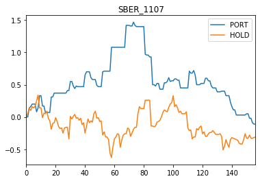

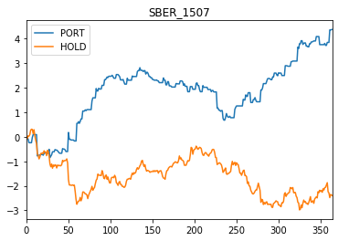

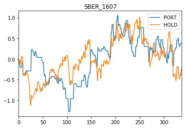

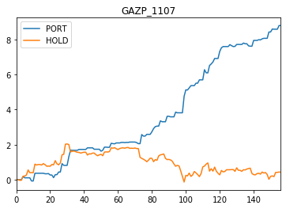

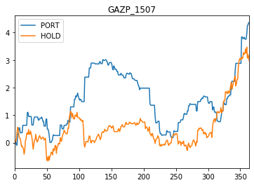

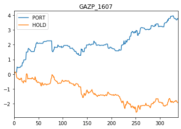

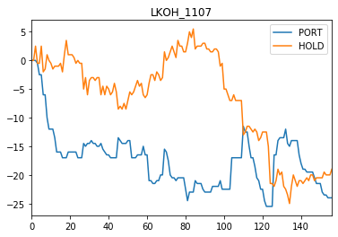

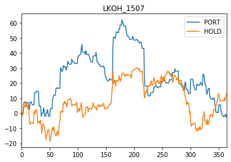

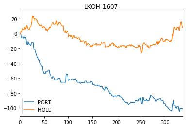

```python
# Дата Фрейм с результатами
port_result = DF()
for name in all_names:
    # Параметры окна
    hight_window = 80
    low_window = 1
    step = hight_window - 1
    # Вспомогательные списки
    flag = []
    bids = []
    offers = []
    lasts = []
    while hight_window < len(globals()[name]):
        # создадим тренировочную выборку
        train = globals()[name].loc[low_window:hight_window-1]
        # Поделим каждое значение на предыдущее, оставим прежним только параметр GROW
        train = train.apply(lambda x: round(x/x.shift(1), 5))
        train.GROW = globals()[name].loc[low_window:hight_window-1].GROW
        # Замена встречащихся inf на nan
        train = train[np.isfinite(train).all(1)].dropna()
        y = train.GROW # зависимая переменная
        X = train.drop('GROW', axis=1) # Независимые переменные
        # Pассчитаем дерево решения
        best_clf = GridSearchCV(DecisionTreeClassifier(),
                                          {'criterion': ['gini', 'entropy'], 'max_depth':range(1, 30)},
                                          iid=True, cv=2).fit(X, y).best_estimator_
        # создадим тестовую выборку
        test = globals()[name].loc[step:hight_window]
        # Добавим необходимые параметры в вспомогательный датафрейм
        bids.append(test['BID'][hight_window])
        offers.append(test['OFFER'][hight_window])
        lasts.append(test['LAST'][hight_window])
        # Поделим каждое значение на предыдущее, оставим прежним только параметр GROW
        test = test.apply(lambda x: round(x/x.shift(1), 5))
        test.GROW = globals()[name].loc[step:hight_window].GROW
        # Замена встречащихся inf на nan
        test = test[np.isfinite(test).all(1)].dropna()
        y_test = test.GROW # зависимая переменная
        X_test = test.drop('GROW', axis=1) # Независимые переменные
        # Добавим флаг
        flag.append(best_clf.predict(X_test))
        # Сдвинимся на шаг вперед
        low_window += 1
        hight_window += 1
        step += 1
    # Заполнение вспомогательного датафрейма
    temp_result =  DF({'BID': bids, 'OFFER': offers, 'LAST': lasts, 'FLAG': flag})
    # ПОсмотрим на резудьтат стратегии и простого удержания акции
    ax = strategy_resilts(temp_result).plot()
    ax = ax.set_title(name)
    #Тест стратегии
    port_result[name] = strategy_resilts(temp_result).loc[len(temp_result)-1]
port_result.index = ['PORT', 'HOLD']
```

|  | PORT | HOLD |
| --- | --- | --- |
| SBER_1107 | -0.11 | -0.31 |
| SBER_1507 | 4.38 | -2.40 |
| SBER_1607 | 0.38 | -0.33 |
| GAZP_1107 | 8.80 | 0.43 |
| GAZP_1507 | 4.36 | 2.96 |
| GAZP_1607 | 3.75 | -1.93 |
| LKOH_1107 | -24.00 | -19.00 |
| LKOH_1507 | -2.00 | 13.00 |
| LKOH_1607 | -101.50 | 9.50 |

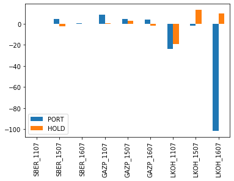

```python
# Для простоты понимания и работы, транспонируем таблицу с результатами
port_result = port_result.transpose()
port_result
ax = port_result.plot.bar()
```

Результаты стратегии показали отрицательные результаты на Лукойле. Посмотрим на параметры выборок: среднее значение $bid - offer$ спреда, среднее значение доходности и стандартное отклонение доходности. И посмотри на зависимость результата стратегии от полученных параметров.

```python
# Подсчет и отображение данных регрессии
import statsmodels.api as sm
# Функция для среднего значения
def mean_series(df, column='LAST'):
    return np.mean(np.array(DF(df[column]).apply(lambda x: np.log(x/x.shift(1))).dropna()))

# Функция для стандартного отклонения
def std_series(df, column='LAST'):
    return np.std(np.array(DF(df[column]).apply(lambda x: np.log(x/x.shift(1))).dropna()))

# Функция для спреда
def spread_series(df, columns=['OFFER', 'BID']):
    return np.mean(df[columns[0]] - df[columns[1]])
```

```python
port_result['MEAN'] = 0
port_result['SD'] = 0
port_result['SPREAD'] = 0
# Разница между стратегией и удержанием
port_result['GET'] = port_result['PORT'] - port_result['HOLD']
for row in port_result.index:
    port_result.loc[row, 'MEAN'] = round(mean_series(globals()[row]), 6)
    port_result.loc[row, 'SD'] = round(std_series(globals()[row]), 6)
    port_result.loc[row, 'SPREAD'] = round(spread_series(globals()[row]), 4)
port_result
```

|  | PORT | HOLD | MEAN | SD | SPREAD | GET |
| --- | --- | --- | --- | --- | --- | --- |
| SBER_1107 | -0.11 | -0.31 | -0.000034 | 0.000423 | 0.0396 | 0.20 |
| SBER_1507 | 4.38 | -2.40 | 0.000001 | 0.000637 | 0.0505 | 6.78 |
| SBER_1607 | 0.38 | -0.33 | -0.000008 | 0.000516 | 0.0449 | 0.71 |
| GAZP_1107 | 8.80 | 0.43 | -0.000020 | 0.000606 | 0.0464 | 8.37 |
| GAZP_1507 | 4.36 | 2.96 | -0.000043 | 0.000604 | 0.0581 | 1.40 |
| GAZP_1607 | 3.75 | -1.93 | -0.000023 | 0.000472 | 0.0347 | 5.68 |
| LKOH_1107 | -24.00 | -19.00 | -0.000039 | 0.000451 | 1.3101 | -5.00 |
| LKOH_1507 | -2.00 | 13.00 | -0.000033 | 0.000549 | 1.4506 | -15.00 |
| LKOH_1607 | -101.50 | 9.50 | -0.000010 | 0.000462 | 1.2656 | -111.00 |

Уже можно увидеть что при высоком значении спреда результат получается отрицательный. Посмортим на зависимость результата от параметров, используя множественную регрессию.

```python
# Независимые переменные
X = port_result.loc[:, ['MEAN', 'SD', 'SPREAD']]
# Зависимая переменная
y = port_result['GET']
# Смещение
x2 = sm.add_constant(X)
est = sm.OLS(y, x2)
est2 = est.fit()
print(est2.summary())
```

```
                            OLS Regression Results
==============================================================================
Dep. Variable:                    GET   R-squared:                       0.548
Model:                            OLS   Adj. R-squared:                  0.277
Method:                 Least Squares   F-statistic:                     2.021
Date:                Sun, 04 Aug 2019   Prob (F-statistic):              0.230
Time:                        22:56:33   Log-Likelihood:                -41.357
No. Observations:                   9   AIC:                             90.71
Df Residuals:                       5   BIC:                             91.50
Df Model:                           3
Covariance Type:            nonrobust
==============================================================================
                 coef    std err          t      P>|t|      [0.025      0.975]
------------------------------------------------------------------------------
const        -87.1150     91.153     -0.956      0.383    -321.432     147.202
MEAN       -1.078e+06   7.82e+05     -1.379      0.226   -3.09e+06    9.31e+05
SD          1.274e+05   1.57e+05      0.810      0.455   -2.77e+05    5.32e+05
SPREAD       -35.0317     18.702     -1.873      0.120     -83.106      13.043
==============================================================================
Omnibus:                        2.909   Durbin-Watson:                   1.594
Prob(Omnibus):                  0.234   Jarque-Bera (JB):                1.409
Skew:                          -0.954   Prob(JB):                        0.494
Kurtosis:                       2.659   Cond. No.                     8.39e+04
==============================================================================

Warnings:
[1] Standard Errors assume that the covariance matrix of the errors is correctly specified.
[2] The condition number is large, 8.39e+04. This might indicate that there are
strong multicollinearity or other numerical problems.
```

# Стратегия с использованием рандомного леса

## Методика расчёта стратегии

Методика будет такой-же как и у дерева решений. В начале также определяется длинна расчетного окна. Расчёт окна будет проводиться на выборке $10$ - $100$ фреймов с шагом $10$ фреймов одного дня, потом эти расчеты будут производить на других днях и будет выбрана самая стабильная длина расчётного окна.

```
Лучшие параметры классификатора: {'criterion': 'gini', 'max_depth': 8, 'n_estimators': 18}
Доля верно предсказанных значений тренированного классификатора на тестовой выборке: 0.5063
```

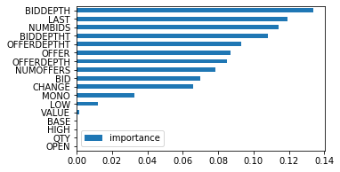

```python
# Подгрузим пакет для построения рандомного леса
from sklearn.ensemble import RandomForestClassifier
# Создание рандоиного леса
clf_rf = RandomForestClassifier()
# Создадим тестовую и проверочную выборку
X = SBER_1107.drop('GROW', axis=1)
y = SBER_1107.GROW
X_train, X_test, y_train, y_test =  train_test_split(X, y, test_size=.33, random_state=42)
# Параметры рандомного леса
params = {'criterion': ['gini', 'entropy'], 'n_estimators': range(1, 20), 'max_depth': range(1, 30)}
# Поиск лучших параметров рандомного леса
grid_search_cv_clf_rf = GridSearchCV(clf_rf, params, iid=True, cv=3)
print('Лучшие параметры классификатора:', grid_search_cv_clf_rf.fit(X_train, y_train).best_params_)
best_clf_rf = grid_search_cv_clf_rf.fit(X_train, y_train).best_estimator_
print('Доля верно предсказанных значений тренированного классификатора на тестовой выборке:', round(best_clf_rf.score(X_test, y_test), 4))
imp = pd.DataFrame(best_clf_rf.feature_importances_, index=X_train.columns, columns=['importance'])
ax = imp.sort_values('importance').plot(kind='barh', figsize=(5, 3))
```

Как видно, основные факторы изменились. Теперь их значительно больше и мы можем предположить, что результаты будут более стабильными. Однако эффективность которую показал данный классификатор имеет достаточно низкую точность. Попробуем посмотреть как он(классификатор) ведёт себя при различной длине рассчётнного окна.

```python
forest_results = DF()
step = 110
for name in all_names:
    results = []
    for window_leigth in range(10, step, 10):
        # создадим тренировочную выборку
        train = globals()[name].loc[1:window_leigth]
        y = train.GROW # зависимая переменная
        X = train.drop('GROW', axis=1) # Независимые переменные
        # Создадим рандомный лес
        ## Параметры модели
        params = {'criterion': ['gini', 'entropy'], 'n_estimators':range(1, 20), 'max_depth': range(1, 20)}
        # Создаем дерево решений с лучшими параметрами
        grid_search_cv_clf_rf = GridSearchCV(RandomForestClassifier(), parametrs, iid=True, cv=2)
        # Тренируем дерево решений
        best_clf_rf = grid_search_cv_clf_rf.fit(X, y).best_estimator_
        # создадим тестовую выборку
        test = globals()[name].loc[window_leigth:]
        y_test = test.GROW # зависимая переменная
        X_test = test.drop('GROW', axis=1) # Независимые переменные
        # Эффективность тренированного дерева решений
        res = best_clf_rf.score(X_test, y_test)
        results.append(res)
    forest_results[name] = results
forest_results.index = [str(i) for i in range(10, step, 10)]
forest_results.index.name = 'Step_leight'
forest_results['MEAN'] = 0
forest_results['MEAN'] = tree_results.sum(axis = 1) / len(tree_results.columns)
forest_results
```

| Step_leight | SBER_1107 | SBER_1507 | SBER_1607 | GAZP_1107 | GAZP_1507 | GAZP_1607 | LKOH_1107 | LKOH_1507 | LKOH_1607 | MEAN |
| --- | --- | --- | --- | --- | --- | --- | --- | --- | --- | --- |
| 10 | 0.458150 | 0.436782 | 0.463235 | 0.537445 | 0.579310 | 0.580882 | 0.392070 | 0.413793 | 0.571078 | 0.518360 |
| 20 | 0.534562 | 0.456471 | 0.537688 | 0.525346 | 0.423529 | 0.424623 | 0.410138 | 0.574118 | 0.464824 | 0.542095 |
| 30 | 0.526570 | 0.453012 | 0.466495 | 0.507246 | 0.414458 | 0.530928 | 0.589372 | 0.445783 | 0.432990 | 0.553546 |
| 40 | 0.482234 | 0.545679 | 0.460317 | 0.563452 | 0.570370 | 0.425926 | 0.416244 | 0.575309 | 0.428571 | 0.614613 |
| 50 | 0.513369 | 0.551899 | 0.535326 | 0.491979 | 0.584810 | 0.448370 | 0.443850 | 0.577215 | 0.510870 | 0.607903 |
| 60 | 0.480226 | 0.563636 | 0.539106 | 0.502825 | 0.537662 | 0.480447 | 0.621469 | 0.568831 | 0.555866 | 0.573621 |
| 70 | 0.532934 | 0.557333 | 0.537356 | 0.514970 | 0.482667 | 0.459770 | 0.562874 | 0.568000 | 0.563218 | 0.643246 |
| 80 | 0.535032 | 0.558904 | 0.476331 | 0.490446 | 0.575342 | 0.452663 | 0.484076 | 0.476712 | 0.420118 | 0.763424 |
| 90 | 0.476190 | 0.481690 | 0.469512 | 0.571429 | 0.569014 | 0.484756 | 0.530612 | 0.447887 | 0.591463 | 0.715470 |
| 100 | 0.540146 | 0.542029 | 0.468553 | 0.518248 | 0.588406 | 0.540881 | 0.598540 | 0.481159 | 0.622642 | 0.727768 |

```python
forest_results_update = DF()
step = 110
for name in all_names:
    results = []
    for window_leigth in range(10, step, 10):
        # создадим тренировочную выборку
        train = globals()[name].loc[1:window_leigth]
        # Поделим каждое значение на предыдущее, оставим прежним только параметр GROW
        train = train.apply(lambda x: round(x/x.shift(1), 5))
        train.GROW = globals()[name].loc[1:window_leigth].GROW
        # Замена встречащихся inf на nan
        train = train[np.isfinite(train).all(1)]
        train = train.dropna()
        y = train.GROW # зависимая переменная
        X = train.drop('GROW', axis=1) # Независимые переменные
        # рассчитаем дерево решения
        ## Параметры модели
        params = {'criterion': ['gini', 'entropy'], 'n_estimators':range(1, 20), 'max_depth': range(1, 20)}
        # Создаем дерево решений с лучшими параметрами
        grid_search_cv_clf_rf = GridSearchCV(RandomForestClassifier(), parametrs, iid=True, cv=2)
        # Тренируем дерево решений
        best_clf_rf = grid_search_cv_clf_rf.fit(X, y).best_estimator_
        # создадим тестовую выборку
        test = globals()[name].loc[window_leigth:]
        # Поделим каждое значение на предыдущее, оставим прежним только параметр GROW
        test = test.apply(lambda x: round(x/x.shift(1), 5))
        test.GROW = globals()[name].loc[window_leigth:].GROW
        # Замена встречащихся inf на nan
        test = test[np.isfinite(test).all(1)]
        test = test.dropna()
        y_test = test.GROW # зависимая переменная
        X_test = test.drop('GROW', axis=1) # Независимые переменные
        # Эффективность тренированного дерева решений
        res = best_clf_rf.score(X_test, y_test)
        results.append(res)
    forest_results_update[name] = results
forest_results_update.index = [str(i) for i in range(10, step, 10)]
forest_results_update['mean'] = 0
forest_results_update['mean'] = tree_results.sum(axis=1) / len(tree_results.columns)
forest_results_update.index.name = 'Step_leight'
forest_results_update
```

| Step_leight | SBER_1107 | SBER_1507 | SBER_1607 | GAZP_1107 | GAZP_1507 | GAZP_1607 | LKOH_1107 | LKOH_1507 | LKOH_1607 | mean |
| --- | --- | --- | --- | --- | --- | --- | --- | --- | --- | --- |
| 10 | 0.477876 | 0.458525 | 0.535627 | 0.504425 | 0.424942 | 0.579853 | 0.548673 | 0.582949 | 0.560197 | 0.496894 |
| 20 | 0.523148 | 0.518868 | 0.561713 | 0.611111 | 0.557920 | 0.579345 | 0.518519 | 0.580189 | 0.551637 | 0.546452 |
| 30 | 0.631068 | 0.628019 | 0.589147 | 0.626214 | 0.600484 | 0.532300 | 0.572816 | 0.685990 | 0.583979 | 0.565578 |
| 40 | 0.494898 | 0.603960 | 0.623342 | 0.556122 | 0.571782 | 0.511936 | 0.571429 | 0.735149 | 0.607427 | 0.601212 |
| 50 | 0.693548 | 0.598985 | 0.629428 | 0.704301 | 0.672589 | 0.569482 | 0.521505 | 0.700508 | 0.623978 | 0.636491 |
| 60 | 0.670455 | 0.601562 | 0.638655 | 0.755682 | 0.580729 | 0.582633 | 0.590909 | 0.710938 | 0.613445 | 0.632104 |
| 70 | 0.596386 | 0.606952 | 0.616715 | 0.626506 | 0.652406 | 0.677233 | 0.674699 | 0.671123 | 0.685879 | 0.646115 |
| 80 | 0.730769 | 0.708791 | 0.771513 | 0.756410 | 0.640110 | 0.721068 | 0.698718 | 0.708791 | 0.685460 | 0.660262 |
| 90 | 0.650685 | 0.638418 | 0.626911 | 0.568493 | 0.641243 | 0.727829 | 0.582192 | 0.728814 | 0.795107 | 0.701956 |
| 100 | 0.632353 | 0.668605 | 0.574132 | 0.764706 | 0.677326 | 0.772871 | 0.801471 | 0.677326 | 0.706625 | 0.697751 |

## Рассчитаем стратегию и стравним её с обычным удержанием

Ход расчёта стратегии такой же, как и у дерева решений.

|  | PORT | HOLD |
| --- | --- | --- |
| SBER_1107 | -2.84 | 0.26 |
| SBER_1507 | -8.50 | 2.32 |
| SBER_1607 | -5.22 | -0.33 |
| GAZP_1107 | -4.13 | -0.46 |
| GAZP_1507 | -6.37 | -3.09 |
| GAZP_1607 | -2.87 | 1.81 |
| LKOH_1107 | -42.00 | 15.50 |
| LKOH_1507 | -238.00 | 13.00 |
| LKOH_1607 | -209.50 | -13.00 |

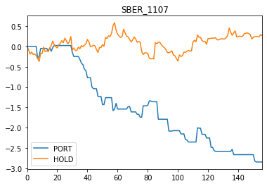

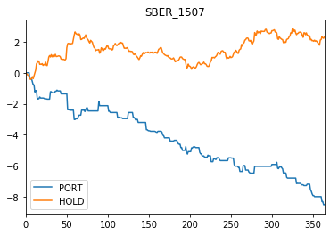

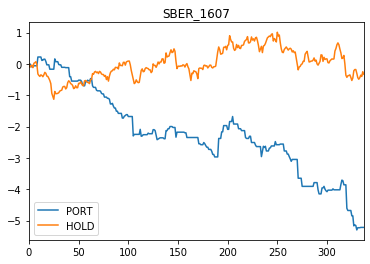

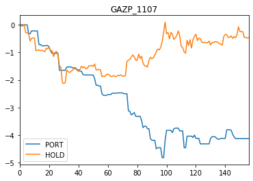

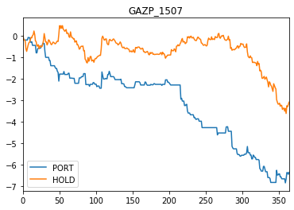

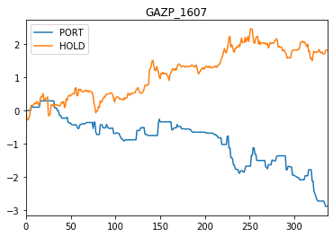

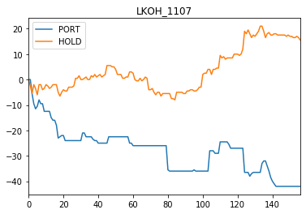

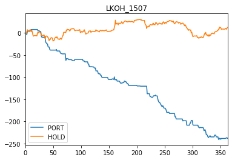

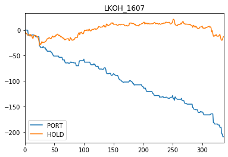

```python
# Дата Фрейм с результатами
forrest_port_result = DF()
for name in all_names:
    # Параметры окна
    hight_window = 80
    low_window = 1
    # Вспомогательные списки
    flag = []
    bids = []
    offers = []
    lasts = []
    while hight_window < len(globals()[name]):
        # создадим тренировочную выборку
        train = globals()[name].loc[low_window:hight_window-1]
        y = train.GROW # зависимая переменная
        X = train.drop('GROW', axis=1) # Независимые переменные
        # Pассчитаем рандомный лес
        params = {'criterion': ['gini', 'entropy'], 'n_estimators':range(1, 20), 'max_depth': range(1, 20)}
        # Создаем дерево решений с лучшими параметрами
        grid_search_cv_clf_rf = GridSearchCV(RandomForestClassifier(), parametrs, iid=True, cv=2)
        # Тренируем рандомный лес
        best_clf_rf = grid_search_cv_clf_rf.fit(X, y).best_estimator_
        # создадим тестовую выборку
        test = DF(globals()[name].loc[hight_window]).T
        # Добавим необходимые параметры в вспомогательный датафрейм
        bids.append(test['BID'][hight_window])
        offers.append(test['OFFER'][hight_window])
        lasts.append(test['LAST'][hight_window])
        y_test = test.GROW # зависимая переменная
        X_test = test.drop('GROW', axis=1) # Независимые переменные
        # Добавим флаг
        flag.append(best_clf_rf.predict(X_test))
        # Сдвинимся на шаг вперед
        low_window += 1
        hight_window += 1
    # Заполнение вспомогательного датафрейма
    temp_result =  DF({'BID': bids, 'OFFER': offers, 'LAST': lasts, 'FLAG': flag})
    # ПОсмотрим на резудьтат стратегии и простого удержания акции
    ax = strategy_resilts(temp_result).plot()
    ax = ax.set_title(name)
    #Тест стратегии
    forrest_port_result[name] = strategy_resilts(temp_result).loc[len(temp_result)-1]
forrest_port_result.index = ['PORT', 'HOLD']
forrest_port_result = forrest_port_result.transpose()
forrest_port_result
```